# STAT 321 Project Report

Ian Cummings, Akhil Ghosh

12/13/2021

## Appendix

[figure not shown]

[output not shown]

[output not shown]

[output not shown]

[output not shown]

## Introduction:

In the sport of Cross Country distance running, scoring has traditionally been done through a rank-sum scoring system. This system just sums up the first 5 place finishers for each team, giving a final rank for each team. While this system is quite simple and intuitive, causing it to be widely popular among runners, it does pose issues as it can lead to situations that violate the independence of irrelevant alternatives assumptions. This means that a team’s performances are not independent of one another, and the presence or disappearance of a team can lead to different results. For example, in a three team meet, team one may initially win the entire thing. However, if one removes team three, team two may end up beating team one. This is an example of a violation of the IIA, and is why in these simulations we explore different scoring systems in order to see which one has the least violations of the IIA.

We have to shoutout Quang, as his simulations on the climbing and the exploration of that scoring systems was what even prompted us to explore cross country scoring. He also gave a us a couple links that were very helpful in our simulations.

Links: https://www.sciencedirect.com/science/article/pii/S0165489614000249 https://qntkhvn.netlify.app/posts/2021-07-31-climbing-p1-sim

## Methods

Initially, we set up a way to simulate places and scoring of a cross country meet using a uniform distribution for places, for a specified number of teams and runners for each team. This allowed us to then code different scoring functions, like the rank sum scoring and rank product scoring functions to explore different methods of scoring a cross country meet. Rank Sum scoring, like discussed earlier simply adds the top 5 scores of each runner for a team. Rank product scoring, on the other hand, multiplies the top 5 places for each team to determine the score. This places heavy emphasis on having a runner place in the top 5/10 as it will drastically reduce the team score in comparison to rank sum scoring. We also included a drop team function, which would drop a specified team, and re-place the entire meet removing the runners from the team that was dropped. All of this allowed us to explore possible violations of the IIA as each team was dropped in a theoretical simulation. For our specific simulation, we decided to simulate the NCAA XC nationals meet, as it is the most important race of the cross country season. This meet has 31 teams, each with 7 runners each. We then utilized the different scoring functions, and dropped each of the 31 teams to see the number of IIA violations for each scoring system. We were able to use another function called count_violations, which would count the number of IIA violations that occurred in each of the 31 drops. Using this function, we were able to compare the different scoring systems to each other, and see which scoring systems had more occurrences of violations in comparison to each other.

## Results

First we looked at the distributions of first-place runners across the top-five teams, and calculated the probability of getting a top five team score given you had the overall meet winner.

# Rank Sum

Here we use a rank sum scoring system, were we chose the sum of the first 5 runners to be the score.

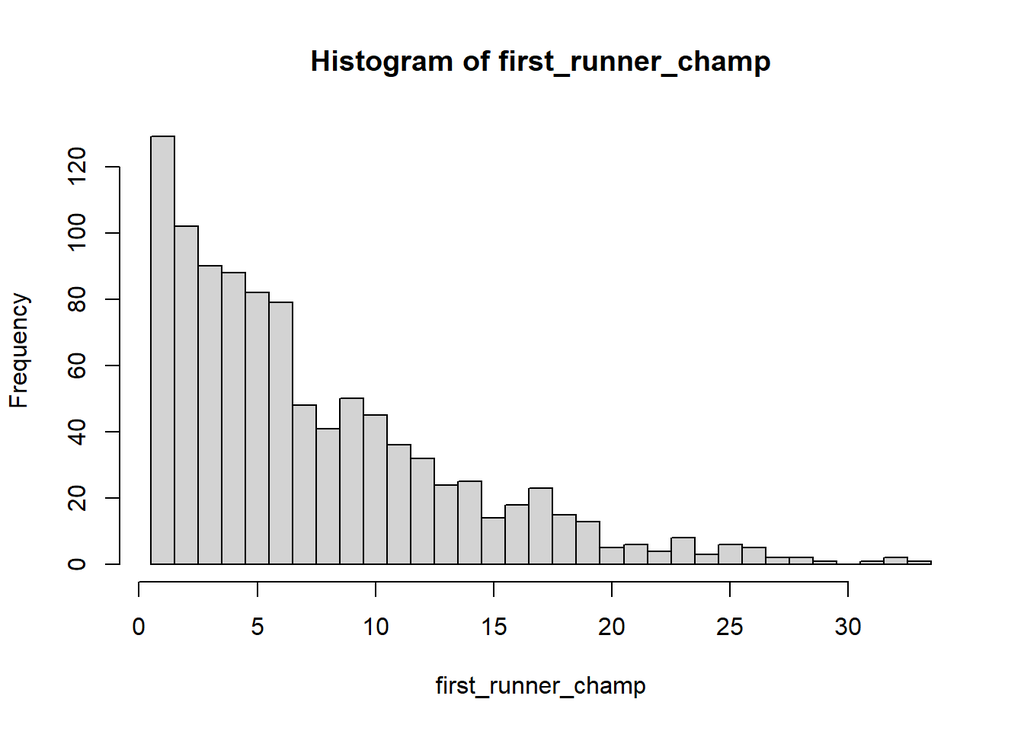

```r
set.seed(69420)
nsim <- 10000
top10_all <- c()
top3_all <- c()
champ_all <- c()
second_all <- c()
third_all <- c()
tenth_all <- c()
#Vector containing first scoring team member of winning team for each simulation
first_runner_champ <- c()
first_runner_second <- c()
first_runner_third <- c()
first_runner_fourth <- c()
first_runner_fifth <- c()
a <-31
b<-7
nsim <-1000
teams_to_drop <- c(17,19)
num_scorers <- 5
#simulations looking at proportions of scoring needed for first, second, third etc
#also looks at how likely you are to win if have the winner of the meet
#could be improved by using empirical data, will attempt in future
for(i in 1:nsim){

  teams <- meet(a, b)
  teams_score <- teams
  a2<-ranksum_scoring(teams,num_scorers)

  for(i in 1:length(teams_score)){
    teams_score[[i]][length(teams_score[[i]])+1] <- a2[i]
  }

  teams_score <- teams_score[order(sapply(teams_score,"[[",b+1))]
  first_runner_champ <- append(first_runner_champ,teams_score[[1]][1])
  first_runner_second <- append(first_runner_second,teams_score[[2]][1])
  first_runner_third <- append(first_runner_third,teams_score[[3]][1])
  first_runner_fourth <- append(first_runner_fourth,teams_score[[4]][1])
  first_runner_fifth <- append(first_runner_fifth,teams_score[[5]][1])


  scores <- sort(a2)
  n <- scores[1:10]
  top3 <- scores[1:3]
  second <- scores[2]
  third <- scores[3]
  champ_score <- scores[1]
  champ_team <- teams_score[[1]]

  tenth <- scores[10]

  top10_all <- append(top10_all, n)
  top3_all <- append(top3_all, top3)
  champ_all <- append(champ_all, champ_score)
  second_all <- append(second_all, second)
  third_all <- append(third_all, third)
  tenth_all <- append(tenth_all,tenth)
}
hist(first_runner_champ, breaks = seq(.5, max(first_runner_champ) + 1))
```

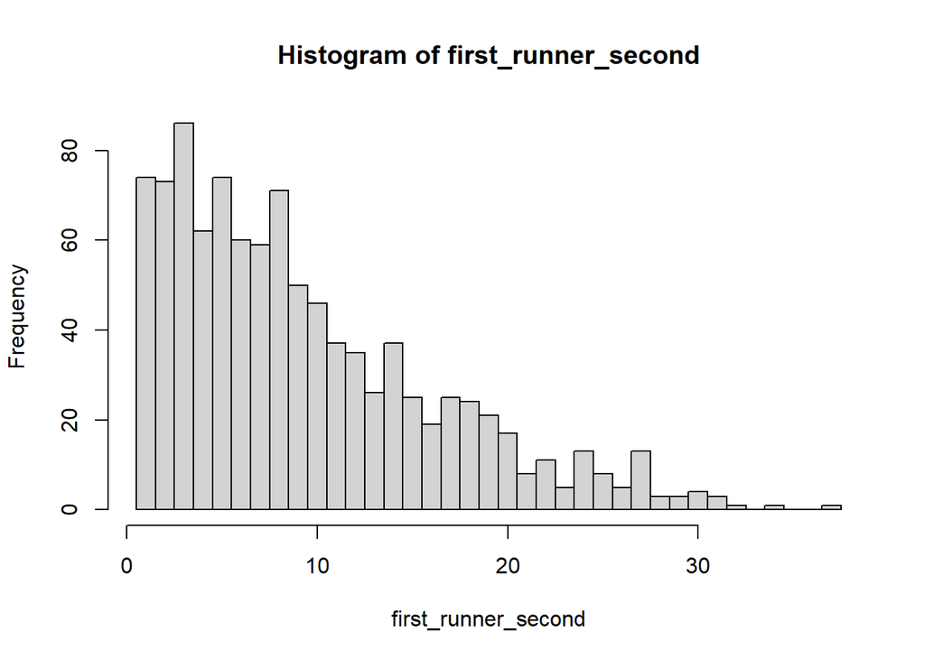

```r
hist(first_runner_second, breaks = seq(.5, max(first_runner_second) + 1))
```

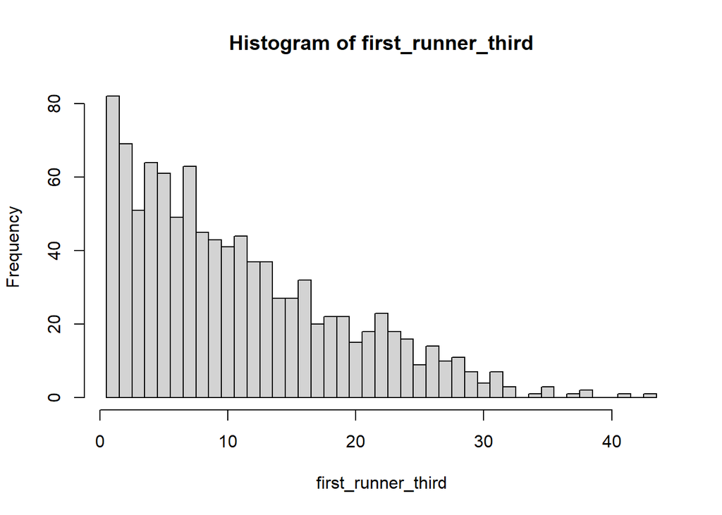

```r
hist(first_runner_third, breaks = seq(.5, max(first_runner_third) + 1))
```

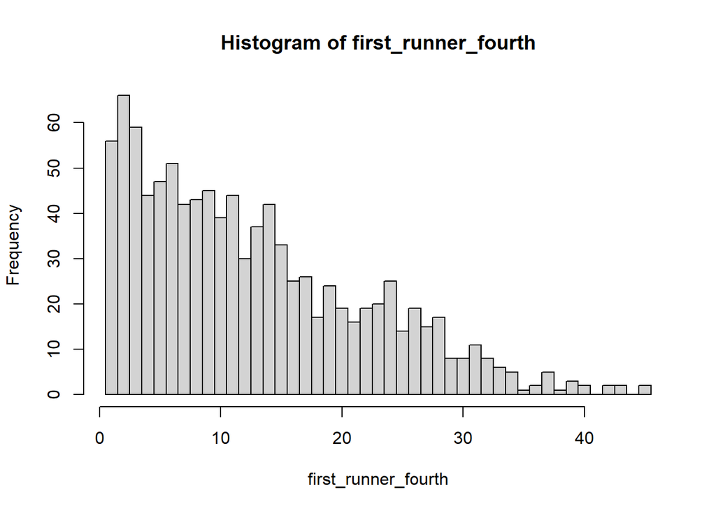

```r
hist(first_runner_fourth, breaks = seq(.5, max(first_runner_fourth) + 1))
```

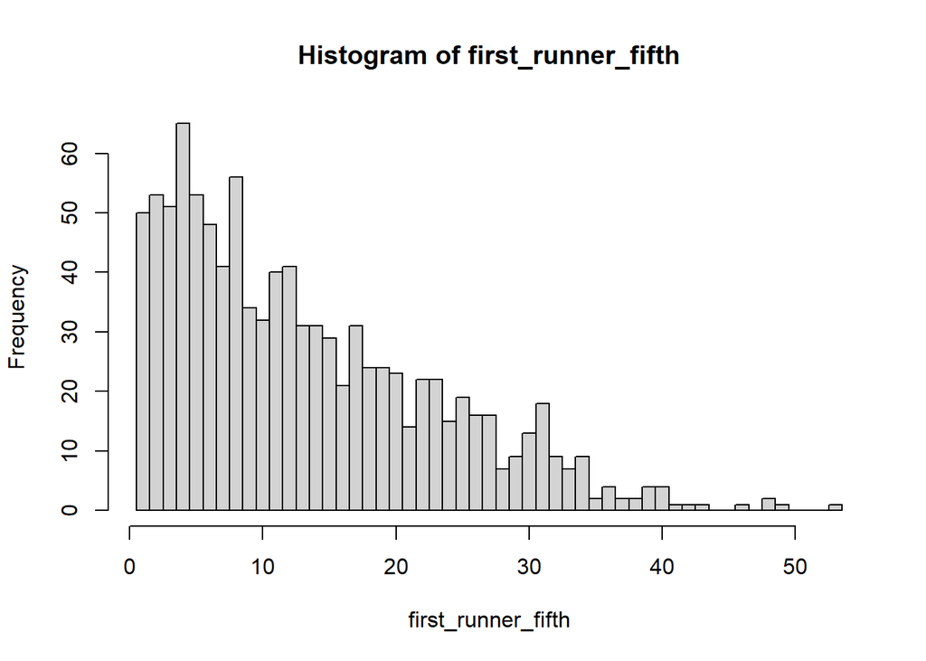

```r
hist(first_runner_fifth, breaks = seq(.5, max(first_runner_fifth) + 1))
```

```r
#probability of getting top 5 team finish given that you have the overall champion
(sum(first_runner_champ == 1) + sum(first_runner_second == 1) + sum(first_runner_third == 1) + sum(first_runner_fourth == 1) + sum(first_runner_fifth == 1)) / nsim
```

```
## [1] 0.391
```

Here we see the probability placing top 5 in team score for the NCAA XC meet given you have the individual meet winner is 39.1%, utilizing the Rank-Sum scoring system

# Rank Product

Again we looked at the distributions of first-place runners across the top-five teams, and calculated the probability of getting a top five team score given you had the overall meet winner, but using the rank product scoring method(in our case the product of the first five runners’ places).

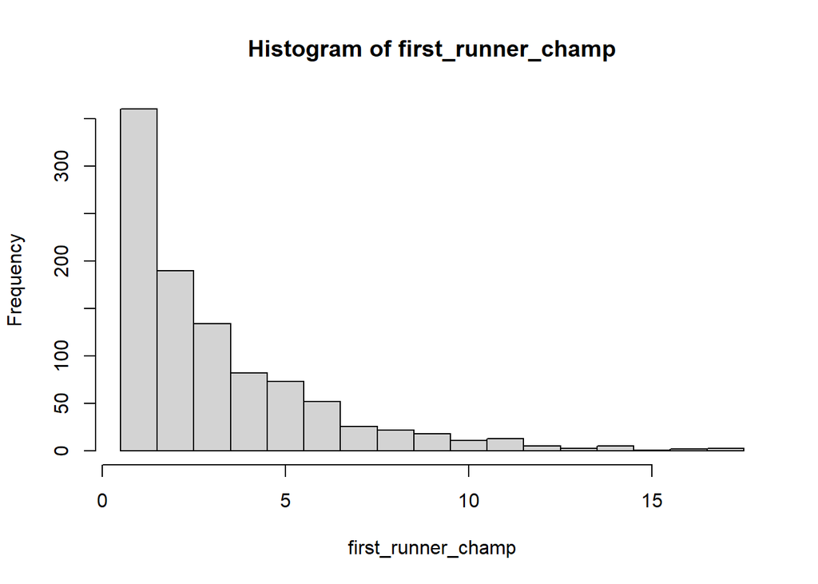

```r
set.seed(69420)
nsim <- 10000
top10_all <- c()
top3_all <- c()
champ_all <- c()
second_all <- c()
third_all <- c()
tenth_all <- c()
#Vector containing first scoring team member of winning team for each simulation
first_runner_champ <- c()
first_runner_second <- c()
first_runner_third <- c()
first_runner_fourth <- c()
first_runner_fifth <- c()
a <-31
b<-7
nsim <-1000
teams_to_drop <- c(17,19)
num_scorers <- 5

#simulations looking at proportions of scoring needed for first, second, third etc
#also looks at how likely you are to win if have the winner of the meet
#could be improved by using empirical data, will attempt in future

for(i in 1:nsim){

  teams <- meet(a, b)
  teams_score <- teams
  a2<-rankproduct_scoring(teams,num_scorers)

  for(i in 1:length(teams_score)){
    teams_score[[i]][length(teams_score[[i]])+1] <- a2[i]
  }

  teams_score <- teams_score[order(sapply(teams_score,"[[",b+1))]
  first_runner_champ <- append(first_runner_champ,teams_score[[1]][1])
  first_runner_second <- append(first_runner_second,teams_score[[2]][1])
  first_runner_third <- append(first_runner_third,teams_score[[3]][1])
  first_runner_fourth <- append(first_runner_fourth,teams_score[[4]][1])
  first_runner_fifth <- append(first_runner_fifth,teams_score[[5]][1])


  scores <- sort(a2)
  n <- scores[1:10]
  top3 <- scores[1:3]
  second <- scores[2]
  third <- scores[3]
  champ_score <- scores[1]
  champ_team <- teams_score[[1]]

  tenth <- scores[10]

  top10_all <- append(top10_all, n)
  top3_all <- append(top3_all, top3)
  champ_all <- append(champ_all, champ_score)
  second_all <- append(second_all, second)
  third_all <- append(third_all, third)
  tenth_all <- append(tenth_all,tenth)
}
hist(first_runner_champ, breaks = seq(.5, max(first_runner_champ) + 1))
```

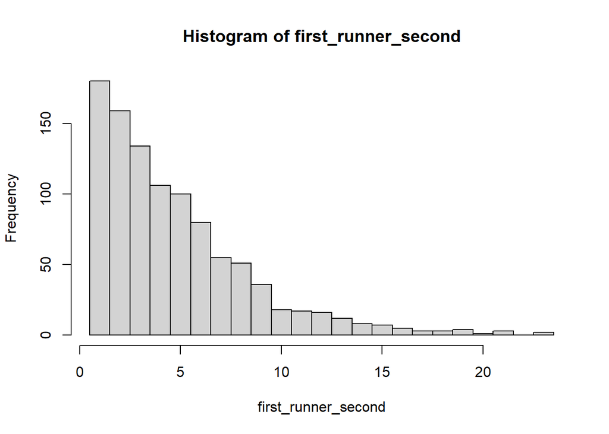

```r
hist(first_runner_second, breaks = seq(.5, max(first_runner_second) + 1))
```

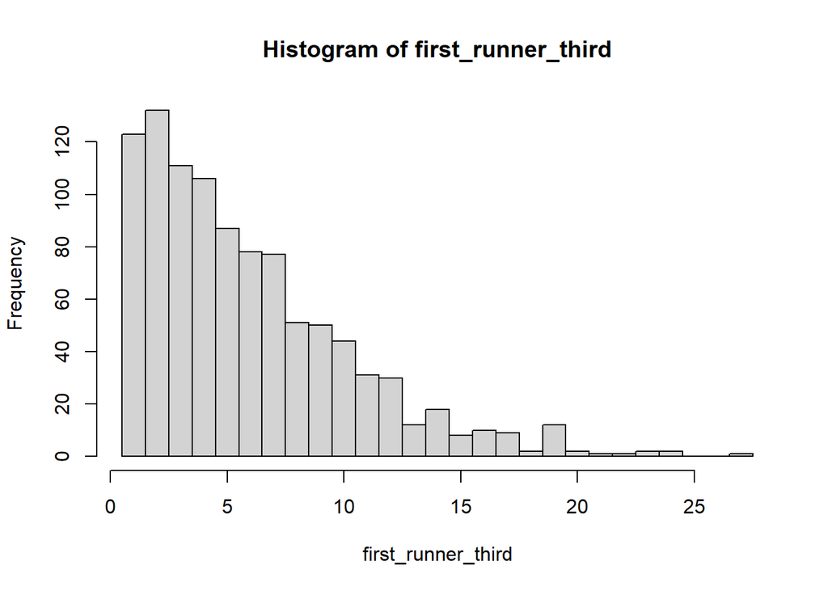

```r
hist(first_runner_third, breaks = seq(.5, max(first_runner_third) + 1))
```

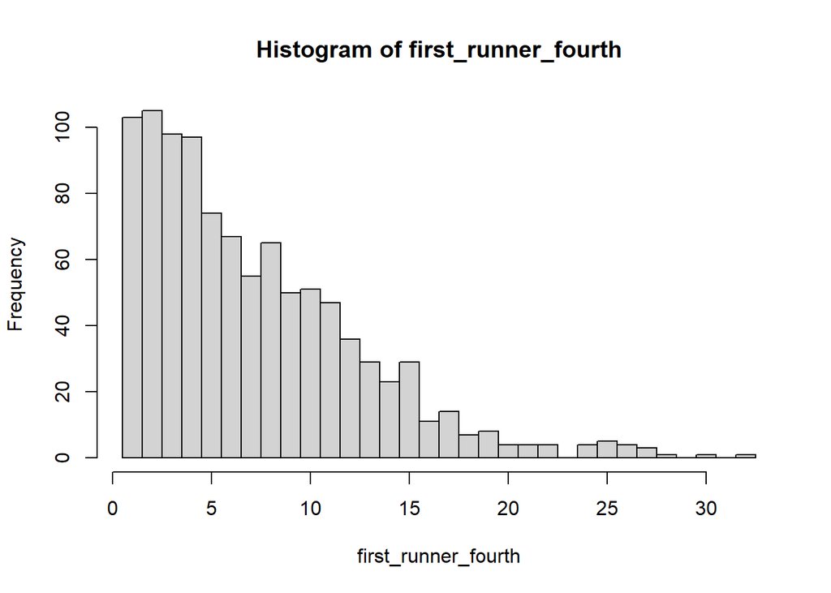

```r
hist(first_runner_fourth, breaks = seq(.5, max(first_runner_fourth) + 1))
```

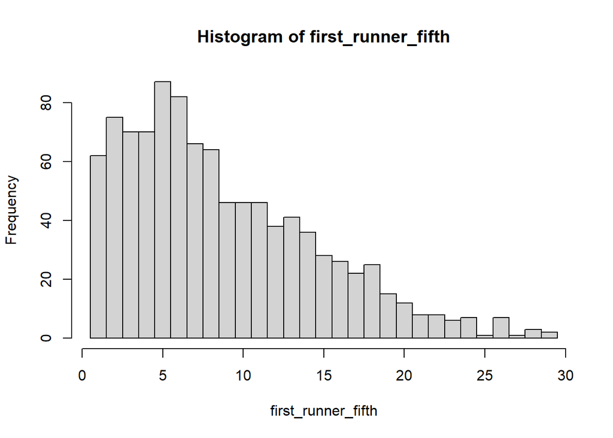

```r
hist(first_runner_fifth, breaks = seq(.5, max(first_runner_fifth) + 1))
```

```r
#probability of getting top 5 team finish given that you have the overall champion
(sum(first_runner_champ == 1) + sum(first_runner_second == 1) + sum(first_runner_third == 1) + sum(first_runner_fourth == 1) + sum(first_runner_fifth == 1)) / nsim
```

```
## [1] 0.828
```

Here we see the probability of placing top 5 in the meet’s team scores with rank-product scoring given you have the individual meet winner is 82.8%.

```r
#Here we utilize the count_violations function in order to determine the number of IIA violations present for Rank-Sum and Rank-Product scoring systems

set.seed(69420)
nsims <- 1000
rs_violations <- 0
rp_violations <- 0
for (i in 1:nsims){
  rs_violations <- rs_violations + count_violations(31, 7, 5, FUN = ranksum_scoring)
  rp_violations <- rp_violations + count_violations(31, 7, 5, FUN = rankproduct_scoring)
}
rs_violations
```

```
## [1] 22781
```

```r
#Rank Sum IIA violations
rp_violations
```

```
## [1] 30979
```

```r
#Rank Product IIA violations
```

## Future work

Both Ian and I want to continue work on this. Honestly, much more work can and (hopefully) will be done, especially in regards to the visualizations and explorations of different scoring systems. While we only got time to finish looking at two specific scoring systems in rank sum and rank product, eventually we want to look at many more scoring methods in order to see which ones produce the lowest number of IIA violations. Since rank-sum still has over 22000 violations, there is a strong possibility for finding a scoring system that produces less IIA violations.

When coding many of these functions, we kept modularity in mind in order to make it easier to build a shiny app that would allow for different sliders and check boxes in order to easily visualize the changes in both scoring systems and meet sizes. While we were unable to finish the shiny app in time for the project, we will continue to work on it. This would be quite interesting, because unlike the previous works done on cross country scoring, giving others the ability to change sliders and visualize changes in IIA and team places would allow for non-statistic cross country folks to understand the ramifications of different scoring methods, and allow them to provide valuable input.

A very strong area for improvement in the modeling, and to hopefully get more realistic results would be making use of empirical data to get a more accurate distributions of team places versus the uniform distribution we used in modeling the meets. This is particularly important, because as it stands right now our median score for the champions of the meet simulations was higher than the recorded highest scoring team in NCAA history. Utilizing empirical data would hopefully allow us to incorporate correlations between places, as high placing teams are not going to follow a uniform distribution of team places. Instead, they are more likely to have a 5 top 40 finishers than the rest of the field. However, we are unsure if we will be able to properly incorporate this.

## Appendix

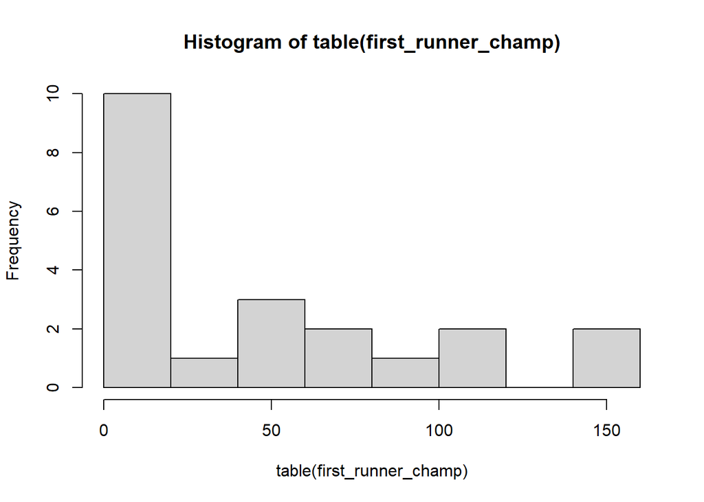

```r
#function for creating an XC meet with n teams of m runners with a uniform distribution
meet <- function(n, m){
  places <- rep(1:(m*n))
  teams <- list()
  for (i in 1:n){
    draw <- sample(places, m)
    draw <- sort(draw)
    teams[[i]] <- draw
    places <- places[!places %in% draw]
  }
  return (teams)
}

#function to score a meet as the sum of the ranks of b runners across a list input, teams, that contains the places of each runner
ranksum_scoring <- function(teams,b){
  scores <- c()
  for(i in 1:length(teams)){
    scores[i] <- sum(teams[[i]][1:b])
    # team[[i]][length(teams[[i]])+1] <<- scores[i]
  }
  return(scores)
}

#function to score a meet as the product of the ranks of b runners across a list input, teams, that contains the places of each runner
rankproduct_scoring <- function(teams, b){
  scores <- rep(1, length(teams))
  for(i in 1:length(teams)){
    for (j in 1:b){
      scores[i] <- scores[i] * teams[[i]][j]
    }
  }
  return(scores)
}

#function to remove a team from a meet and then re-do the places of the runners
drop_1 <- function(teams,remove){
  teams2 <- teams
  teams_drop <- sort(unlist(teams[remove]),decreasing=TRUE)
  # print(teams_drop)
  v<- c(rep(0,length(teams[[1]])))
  v2 <- c(rep(0,length(teams[[1]])))
  for(j in 1:length(teams)){
    if((teams[j] %in% teams[remove])==FALSE){
      for(k in 1:length(teams[[j]])){
        v <- as.integer(teams_drop[k]<unlist(teams[[j]]))
        v2 <- v+v2
      }

      teams2[[j]] <- (teams[[j]] - v2)
      # print(j)
      # print(length(teams[[j]]))
      v2 <- c(rep(0,length(teams[[j]])))

    }

  }
  return(teams2[-remove])
}

#function that calls drop_1 in oder to remove multiple teams
drop_multiple <- function(team,mult){
  team4 <- team

  for(i in 1:length(mult)){
    # print(mult)
    team4 <- drop_1(team4,mult[i])
    mult <- mult-1
    # print(mult)

  }

  return(team4)
}

#Function that takes n # of teams of m runners and n_scorers scoring runners, and a scoring method, and removes every team one-by-one and counts how many times the Independence of Irrelevant Alternatives principle is violated
count_violations <- function(n, m, n_scorers, FUN = ranksum_scoring){
  teams <- meet(n, m)

  scores_i <- FUN(teams, n_scorers)
  team_initials <- paste("Team", c(1:n))
  scores2 <- cbind(team_initials, scores_i)
  scores2 <- scores2[order(scores2[, 2], decreasing = FALSE), ]

  #looping through each team being dropped, counting if IIA was violated
  n_iia_violations <- 0
  for (i in 1:n) {
    #inplace removal
    inplace <- cbind(team_initials[-i], scores_i[-i])
    inplace <- rbind(inplace, c(team_initials[i], "NA"))
    inplace <-  inplace[order(inplace[, 2], decreasing = FALSE), ]
    #dropping team
    teams2 <- drop_multiple(teams, i)
    #removing team name from label
    team_initials2 <- team_initials[-i]
    #rescoring meet aftter dropping team
    scores_i2 <- FUN(teams2, n_scorers)
    #mapping scores to teams
    scores3 <- cbind(team_initials2, scores_i2)
    #sorting by scores
    scores3 <-  scores3[order(scores3[, 2], decreasing = FALSE), ]
    #adding original team as NA
    scores3 <- rbind(scores3, c(team_initials[i], "NA"))
    #comparing inplace switch to dropping, re-placing, and rescoring, and adding it to IIA violation count
    n_iia_violations <-
      n_iia_violations + (sum(!(scores3[, 1] == inplace[, 1])) > 0)
  }
  return (n_iia_violations)
}

nsim <- 1000
top10_all <- c()
top3_all <- c()
champ_all <- c()
second_all <- c()
third_all <- c()
tenth_all <- c()
#Vector containing first scoring team member of winning team for each simulation
first_runner_champ <- c()
first_runner_second <- c()
first_runner_third <- c()
first_runner_fourth <- c()
first_runner_fifth <- c()
a <-22
b<-12
nsim <-1000
teams_to_drop <- c(17,19)
num_scorers <- 5
first_runner_champ <- c()
first_runner_second <- c()
first_runner_third <- c()
first_runner_fourth <- c()
first_runner_fifth <- c()


#simulations looking at proportions of scoring needed for first, second, third etc
#also looks at how likely you are to win if have the winner of the meet
#could be improved by using empirical data, will attempt in future
#Did not include this in the analysis as it's not too interesting without empirical data
#For example, our median score of the champions is higher than any historical NCAA XC nationals champion team score
for(i in 1:nsim){

  teams <- meet(a, b)
  teams_score <- teams
  a2<-ranksum_scoring(teams,num_scorers)


  # length(teams_score)
  # for(i in 1:length(a)){
  #  teams_score[21] <- append(unlist(teams_score[21]), a[21])
  # }

  for(i in 1:length(teams_score)){
    teams_score[[i]][length(teams_score[[i]])+1] <- a2[i]
  }

  teams_score <- teams_score[order(sapply(teams_score,"[[",b+1))]
  first_runner_champ <- append(first_runner_champ,teams_score[[1]][1])
  first_runner_second <- append(first_runner_second,teams_score[[2]][1])
  first_runner_third <- append(first_runner_third,teams_score[[3]][1])
  first_runner_fourth <- append(first_runner_fourth,teams_score[[4]][1])
  first_runner_fifth <- append(first_runner_fifth,teams_score[[5]][1])


  scores <- sort(a2)
  n <- scores[1:10]
  top3 <- scores[1:3]
  second <- scores[2]
  third <- scores[3]
  champ_score <- scores[1]
  champ_team <- teams_score[[1]]

  tenth <- scores[10]

  top10_all <- append(top10_all, n)
  top3_all <- append(top3_all, top3)
  champ_all <- append(champ_all, champ_score)
  second_all <- append(second_all, second)
  third_all <- append(third_all, third)
  tenth_all <- append(tenth_all,tenth)

}

hist(table(first_runner_champ),bins=21)
```

```r
table(first_runner_second)
```

```
## first_runner_second
##   1   2   3   4   5   6   7   8   9  10  11  12  13  14  15  16  17  18  19  20
## 102  95  87 102  83  64  60  64  49  52  36  36  32  26  19  23  18   9   9   9
##  21  22  23  24  25  26  27  29  33
##   3  10   1   2   2   1   3   2   1
```

```r
table(first_runner_third)
```

```
## first_runner_third
##   1   2   3   4   5   6   7   8   9  10  11  12  13  14  15  16  17  18  19  20
## 109  78  88  79  72  61  49  47  49  44  46  40  30  30  27  26  18  25  14  11
##  21  22  23  24  25  26  27  28  31  34  39
##  15  13   4   8   6   4   2   2   1   1   1
```

```r
table(first_runner_fourth)
```

```
## first_runner_fourth
##  1  2  3  4  5  6  7  8  9 10 11 12 13 14 15 16 17 18 19 20 21 22 23 24 25 26
## 58 86 70 58 53 59 54 54 64 47 44 49 39 31 39 40 25 24 23 11 15  7  9 10  5 10
## 27 28 29 30 31 32 33 34 36
##  1  2  3  2  1  1  3  2  1
```

```r
table(first_runner_fifth)
```

```
## first_runner_fifth
##  1  2  3  4  5  6  7  8  9 10 11 12 13 14 15 16 17 18 19 20 21 22 23 24 25 26
## 70 63 60 56 78 52 56 44 42 44 46 31 48 29 24 34 38 27 24 21 19 21 15  7 10  5
## 27 28 29 30 31 32 33 34 35 37
##  9  5  4  4  2  3  3  4  1  1
```